# Refugee Data: Where, When & Why

### Group members: Camille Stacho, Julia D'Zmura, Jordan Mess

#### Introduction:

For this project, we wanted to gain insight into refugees. A refugee is defined as an individual who has been forced to leave their country in order to escape war, persecution, or natural disaster. Recently, there has been a lot of discussion over America's refugee policy as well as the Syrian refugee crisis that has had global effects. And while we had heard a lot about refugees through the news, we had a lot of questions remaining: how many refugees enter countries such as the U.S. each year and how has this amount changed over the past few decades? Historically, what different countries do refugees come from and what age are these refugees? How does country of origin and country of entrance affect whether or not a refugee applicant is accepted or rejected? And finally, what different factors could we use to predict whether or not a refugee is accepted?

The following tutorial will outline how we followed the data lifecycle to gain insight into the questions above as well as come up with a final message based on the insight we gained. For the first three parts we will show how to gather and clean up data, create data visualizations that specifically focus on the questions given above, and finally gather conclusions from these visualizations. Then in part four, we will use machine learning to provide final analysis based on the information we gathered from the first three parts and conclude with a final message.

#### Required Tools

- requests
- pandas
- numpy
- matplotlib
- scikit learn

Resources:

- [WRAPS](http://www.wrapsnet.org/admissions-and-arrivals/)
- [Homeland Security](https://www.dhs.gov/immigration-statistics/refugees-asylees)
- https://data.worldbank.org/indicator/SM.POP.REFG

The following are required imports. We used these libraries to work with dataframes, arrays, and to make plots.

```python
import pandas as pd
import matplotlib.pyplot as plt
import numpy as np
from matplotlib.pyplot import figure
```

#### Part 1:

The first question we decided to tackle was how many refugees there are each year and how this amount has changed over time. We decided to focus on the amount of refugees entering the U.S. as well as some other developed countries in Europe such as France, Germany, the U.K., and Norway (as these are the countries that are often mentioned in the news when discussing the acceptance/rejection of refugees). Below, we open and tidy the csv data file we will use to answer this question.

```python
#OBTAIN DATA FROM THE FIRST CSV
df = pd.read_csv('data/past10.csv')
#DROP COLUMNS WE DO NOT NEED
df.columns = ['Country/territory of asylum/residence', 'Origin', 'Year','Month','Value']
df = df.iloc[3:]

df=df.replace('USA (EOIR)', 'USA')
df=df.replace('USA (INS/DHS)', 'USA')
```

To begin, we decided to look at how many refugees were accepted into the U.S., France, Germany, and Norway in 1999 and 2000. We thought this would give us a general idea of how many refugees are let into these countries in an average year, as well as how this amount can change from year to year.

Below, we create a new dataframe that specifically contains the data from these four countries and groups and sums the amount of refugees each of these countries received by year. Then, we create a stacked bar plot that compares these amounts for 1999 and 2000 in the four countries we chose. The results are shown below.

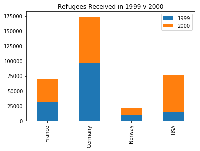

```python
#COMPOSE NEW DATAFRAME OF ONLY THE COUNTRIES THAT WE WANT
country_df = df.loc[df['Country/territory of asylum/residence'] == 'USA']
country_df = country_df.append(df.loc[df['Country/territory of asylum/residence'] == 'Germany'])
country_df = country_df.append(df.loc[df['Country/territory of asylum/residence'] == 'France'])
country_df = country_df.append(df.loc[df['Country/territory of asylum/residence'] == 'Norway'])

country_df['Value'] = pd.to_numeric(country_df['Value'])
country_df = country_df.groupby(['Country/territory of asylum/residence','Year'])['Value'].sum()
country_df=country_df.reset_index()

df1999=country_df.loc[country_df['Year'] == '1999']
df2000=country_df.loc[country_df['Year'] == '2000']

#CREATE A BOX PLOT BY MAKING AN INDEX, THEN PLOTTING THE FIRST V THE SECOND YEAR
index= ['France','Germany','Norway','USA']
firstyear = df1999['Value'].values
secondyear = df2000['Value'].values


df = pd.DataFrame({'1999': firstyear,'2000': secondyear}, index=index)
ax = df.plot.bar(stacked=True,title="Refugees Received in 1999 v 2000")
```

From this graph, we can see that Germany had a much higher amount of refugees entering in both 1999 and 2000 when compared to the U.S., France, and Norway. The U.S. accepted a much greater number of refugees in 2000 than in 1999. France and Norway accepted about the same number of refugees in both years, although they were both lower than Germany and the U.S. in 2000 (probably due to them having an overall smaller population).

We found these facts very interesting, and in order to gain more information on incoming refugees into these countries we decided to look at the number of refugees entering over several years (rather than just two). We could not find data this extensive for Norway, so we decided to look at the U.S., France, Germany, and the U.K. instead.

Below, we begin by reading in the csv data file that has entering refugee data for Germany from 1990-2017. We then tidy up the data by dropping and renaming columns. After that, we plot the population over time for this country.

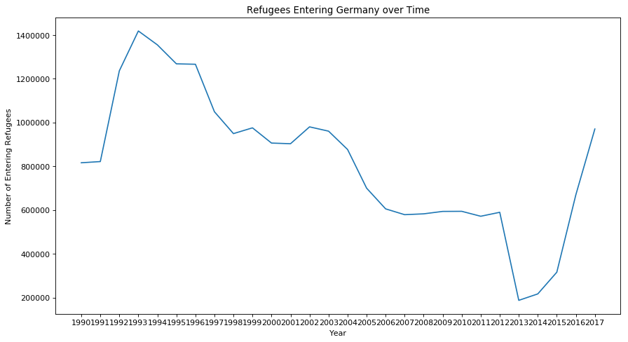

```python
#READ DATA FROM THE SECOND DATA SOURCE, DROP THE COLUMNS WE DO NOT NEED.
df = pd.read_csv('data/world_data.csv')
df = df.drop('Indicator Code',axis=1)
df = df.drop('Indicator Name',axis=1)
#DROP ROWS WE DO NOT NEED.
df= df.drop(df.iloc[:,2:32],axis=1)
#FILL THE NULLS WITH ZEROS.
df = df.fillna(0)

#CREATE THE FIGURE
figure(num=None, figsize=(13, 7), dpi=80, facecolor='w', edgecolor='k')
germ = df.loc[df['Country Code'] == 'DEU']
germ_x=np.array(germ.columns.values)[2:-1]
germ_y=np.array(germ.loc[:,'1990':])[0][:-1]

#ADD THE NECESSARY PLOT ATTRIBUTES AND TITLES
figure(num=None, figsize=(13, 7), dpi=80, facecolor='w', edgecolor='k')
plt.xlabel('Year')
plt.ylabel('Number of Entering Refugees')
plt.title('Refugees Entering Germany over Time')
plt.plot(germ_x,germ_y)
plt.show()
```

We will now do the same thing, but for France. Below, read in the csv data file that has entering refugee data for France from 1990-2017. We then tidy up the data by dropping and renaming columns. After that, we plot the population over time for this country.

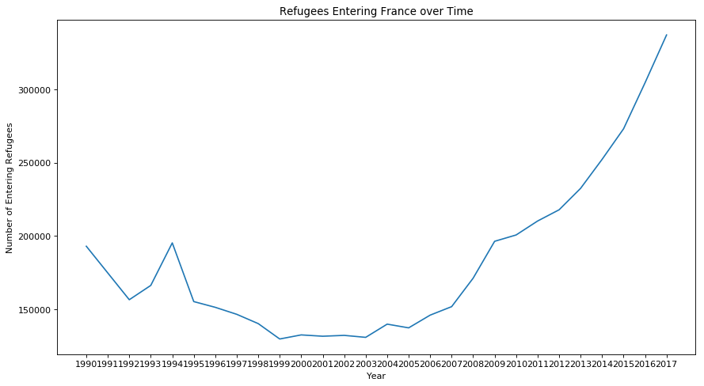

```python
#REPEAT THE SAME PROCESS FOR FRANCE
france = df.loc[df['Country Code'] == 'FRA']
franc_x=np.array(france.columns.values)[2:-1]
franc_y=np.array(france.loc[:,'1990':])[0][:-1]

#ADD NECESSARY TITLES
figure(num=None, figsize=(13, 7), dpi=80, facecolor='w', edgecolor='k')
plt.xlabel('Year')
plt.ylabel('Number of Entering Refugees')
plt.title('Refugees Entering France over Time')
plt.plot(franc_x,franc_y)
```

We will now do the same thing, but for the U.S. Below, read in the csv data file that has entering refugee data for the U.S. from 1990-2017. We then tidy up the data by dropping and renaming columns. After that, we plot the population over time for this country.

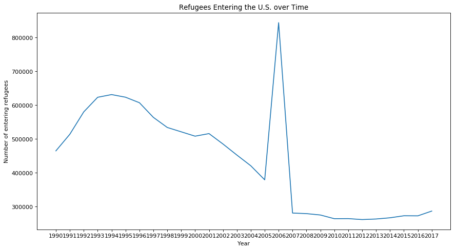

```python
#DO THE SAME THING AGAIN FOR USA
usa = df.loc[df['Country Code'] == 'USA']
usa_x=np.array(usa.columns.values)[2:-1]
usa_y=np.array(usa.loc[:,'1990':])[0][:-1]

#ADD THE TITLES FOR THE PLOT
from matplotlib.pyplot import figure
figure(num=None, figsize=(13, 7), dpi=80, facecolor='w', edgecolor='k')
plt.xlabel('Year')
plt.ylabel('Number of entering refugees')
plt.title('Refugees Entering the U.S. over Time')
plt.plot(usa_x,usa_y)
plt.show()
```

We will now do the same thing, but for U.K. Below, read in the csv data file that has entering refugee data for the U.K. from 1990-2017. We then tidy up the data by dropping and renaming columns. After that, we plot the population over time for this country.

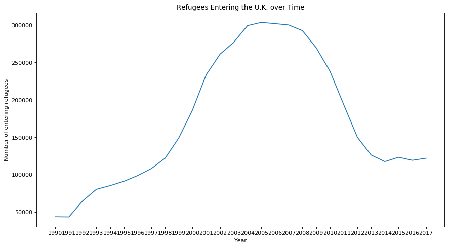

```python
#ADD THE PLOT FOR THE UK
uk = df.loc[df['Country Code'] == 'GBR']
uk_x=np.array(uk.columns.values)[2:-1]
uk_y=np.array(uk.loc[:,'1990':])[0][:-1]

#ADD THE CORRECT TITLES AND PLOT THEM
figure(num=None, figsize=(13, 7), dpi=80, facecolor='w', edgecolor='k')
plt.xlabel('Year')
plt.ylabel('Number of entering refugees')
plt.title('Refugees Entering the U.K. over Time')
plt.plot(uk_x,uk_y)
```

It is currently difficult to compare these plots because they are all showing up seperately. To make this analysis easier, we decided to plot all four line graphs together and have a legend that will tell us which line is for which country. We created this plot below.

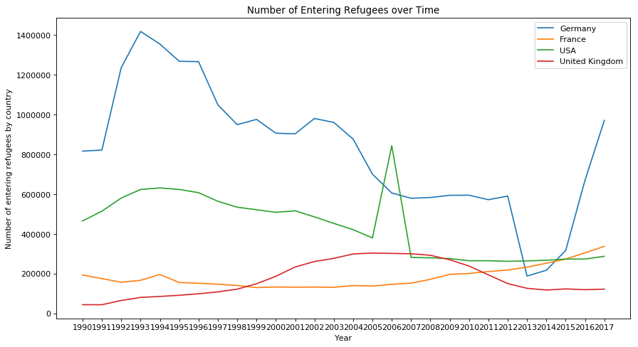

```python
#MAKE A NEW FIGURE TO ADD THE COUNTRIES ALL ON ONE PLOT
figure(num=None, figsize=(13, 7), dpi=80, facecolor='w', edgecolor='k')
plt.xlabel('Year')
plt.ylabel('Number of entering refugees by country')
plt.title('Number of Entering Refugees over Time')

#PLOT EACH COUNTRY
germany = plt.plot(germ_x, germ_y)
france = plt.plot(franc_x, franc_y)
usa = plt.plot(usa_x, usa_y)
uk = plt.plot(uk_x, uk_y)

#ADD A LEGEND
plt.legend(('Germany','France','USA','United Kingdom'))
plt.show()
```

#### Part 2:

After gaining these insights into the number of refugees coming into countries across North America and Europe each year and how this amount has changed over time, we next wanted to learn more about the refugees specifically coming into the U.S.

First, we decided to look at where these refugees come from. Below, we open up the data file that has data on the number of refugees coming from Europe, Asia, Africa, and the Caribbean to the U.S. from 1975-2019 (fiscal years). Then, we clean up this data and create a stacked bargraph showing the number of entrants from each region by year.

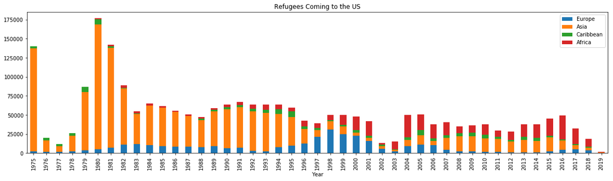

```python
#READ THE NEXT CSV AND ADD APPROPRIATE COLUMNS
dff = pd.read_csv('data/yearstate.csv')
dff.columns = ['Year', 'Africa', 'Asia','NAN','Europe','Union','Kosovo','Caribbean','South Asia','PSI','Total', 'Nan']
dff = dff.iloc[8:].reset_index()
dff = dff.drop(columns=['NAN','Nan','index'])

#CLEAN UP THE COLUMNS
dff=dff.iloc[:45]
dff['Europe'] = dff['Europe'].str.replace(',', '')
dff['Asia'] = dff['Asia'].str.replace(',', '')
dff['Caribbean'] = dff['Caribbean'].str.replace(',', '')
dff['Africa'] = dff['Africa'].str.replace(',', '')

#MAKE ALL OF THE VALUES INTEGERS
index1 = dff['Year']
europe = pd.to_numeric(dff['Europe'].values)
asia = pd.to_numeric(dff['Asia'].values)
caribbean = pd.to_numeric(dff['Caribbean'].values)
africa = pd.to_numeric(dff['Africa'].values)

#PLOT THE DATA USING A STACKED BAR CHART
data = pd.DataFrame({'Europe': europe,'Asia': asia, 'Caribbean': caribbean, 'Africa':africa}, index=index1)
ax1 = data.plot.bar(stacked=True,figsize=(20,5),title="Refugees Coming to the US")
```

This graph gives us a lot of insight into the refugees entering the U.S. and where they come from. For instance, we can see that from 1975-1996 the vast majority of refugees entering the U.S. were coming from Asia, with Europe, Africa, and the Caribbean having varying small amounts in these years. Then, from 1996 until 2006 most refugees entering the U.S. came from Europe and Africa. Finally, from 2007 until 2018 there were large amounts of refugees coming from Africa and Asia into the U.S.

Interestingly, this graph does not show a significant increase in the amount of refugees entering the U.S. in 2006 like we saw in Part 1. This is most likely due to a discrepency in the two different datasets we used.

Next, we decided to look at the age of the refugees entering the U.S. in order to gain more information on this group of people. Below, we read in the data file that has this information for 2016. After tidying up this data, we then created a pie chart that shows the proportion of refugees in 16 different age groups that entered the U.S. in 2016 (these age groups are split up into groups of 5 years). This code and chart and shown below.

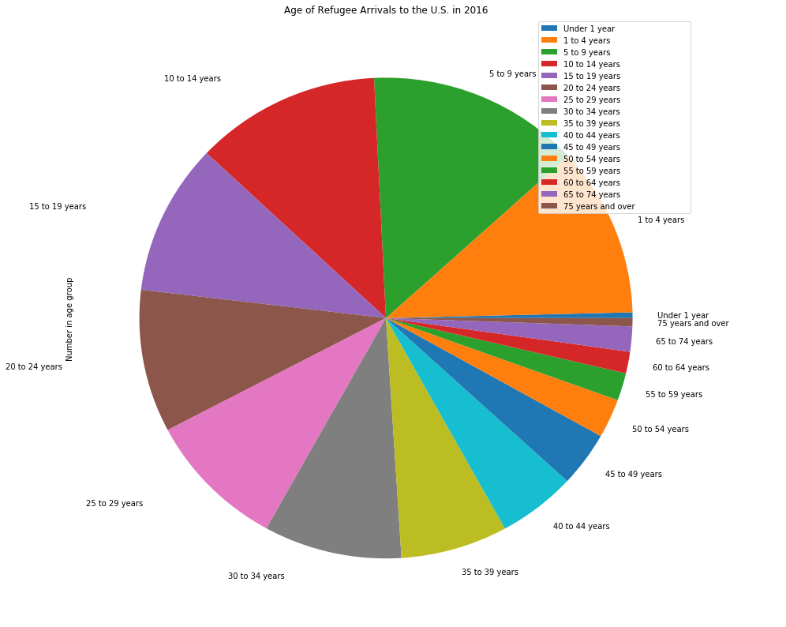

```python
##Homeland security for age in the U.S.:
df = pd.read_excel('HomeLandSecurity/RefugeeArrivalsOther/2016table15.xls')
#RENAME COLUMNS
df.columns = ['Characteristic', 'Total', 'Principal Applicants', 'Spouses', 'Children']

#DROP UNECESSARY COLUMNS
df = df.drop(columns="Principal Applicants")
df = df.drop(columns="Spouses")
df = df.drop(columns="Children")

#CLEAN UP THE DATAFRAME
df_age = df.iloc[10:26]
df_age = df_age.replace(to_replace = "-", value = "0")
df_age = df_age.replace(to_replace = "D", value = "0")

index= df_age['Characteristic'].values
value = pd.to_numeric(df_age['Total']).values

#PLOT A PIE CHART AND SET THE TITLE
df_new = pd.DataFrame({'Number in age group': value}, index=index)
ax1 = df_new.plot.pie(y='Number in age group', figsize=(14,14))
ax1.set_title('Age of Refugee Arrivals to the U.S. in 2016');
```

This chart gives us a lot of insight into the refugees entering the U.S. and what age they were. For instance, it shows that the majority of entering refugees were younger (it is clear that as the age group gets older, the amount of refugees usually decreases). In fact, over 75% of the entering refugees were between 1 and 34 years old. Of course, since this chart is only for data from 2016 we are assuming that these proportions are the typical amounts, at least in recent years.

#### Part 3:

After learning about what types of people are entering the U.S. as refugees (by specifically looking at what regions they are coming from and what age they are) we then wanted to learn more about why these certain people are being accepted into the U.S. One factor we thought would be interesting to consider is where these refugees are coming from.

Below, we read in a data file that contains data on refugee approval rates for refugees coming from different countries across Europe, Asia, and Africa to the U.S. in 2004. Then, we create several stacked bargraphs showing the approval and rejection rates for refugees coming from all of these different countries to the U.S. The first bargraph shows these rates for refugees coming from countries in Europe. The second bargraph shows these rates for refugees coming from countries in Asia. The third bargraph shows these rates for refugees coming from countries in Afria. some countries were listed but did not have any data available, thus they do not have any bars on the graph.

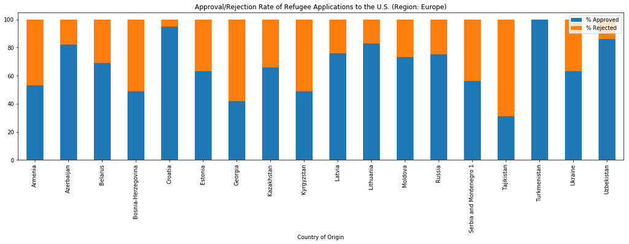

```python
##Homeland security for % approved per country:
df = pd.read_csv('HomeLandSecurity/RefugeeApplications/2004table13CSV.csv')
#DROP ALL THE UNECESSARY COLUMNS
df = df.drop(columns="Unnamed: 1")
df = df.drop(columns="Unnamed: 2")
df = df.drop(columns="Unnamed: 3")
df = df.drop(columns="Unnamed: 4")
df = df.drop(columns="Unnamed: 6")
df = df.drop(columns="Unnamed: 7")
df = df.drop(columns="Unnamed: 8")
df = df.drop(columns="Unnamed: 9")
df = df.drop(columns="Unnamed: 10")
df = df.drop(columns="Unnamed: 11")
df.columns = ['Region and country of birth', 'Percent approved']
df_europe = df.iloc[9:27]

#CREATE THE CORRECT INDEX
index= df_europe['Region and country of birth'].values
percentApproved = pd.to_numeric(df_europe['Percent approved']).values
percentRejected = 100 - pd.to_numeric(df_europe['Percent approved']).values

#PLOT THE DATA USING A STACKED BAR GRAPH
df_new = pd.DataFrame({'% Approved': percentApproved, '% Rejected':percentRejected }, index=index)
ax1 = df_new.plot.bar(stacked=True,figsize=(20,5));
ax1.set_xlabel('Country of Origin');
ax1.set_title('Approval/Rejection Rate of Refugee Applications to the U.S. (Region: Europe)');
```

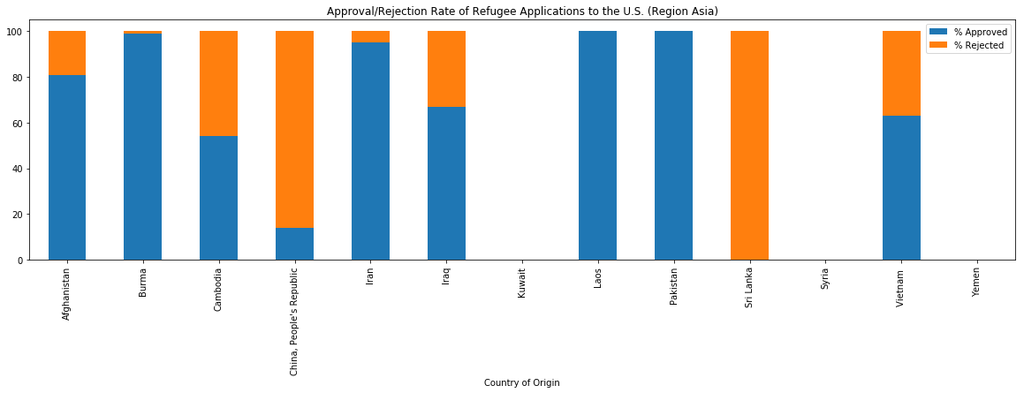

```python
#MAKE A NEW DATAFRAME FOR ASIA

df_asia = df.iloc[28:41]

#CLEAN UP THE VALUES
index= df_asia['Region and country of birth'].values
percentApproved = pd.to_numeric(df_asia['Percent approved']).values
percentRejected = 100 - pd.to_numeric(df_asia['Percent approved']).values

#MAKE A NEW DATAFRAME WITH A STACKED BAR ATTRIBUTE
df_new = pd.DataFrame({'% Approved': percentApproved, '% Rejected':percentRejected }, index=index)
ax1 = df_new.plot.bar(stacked=True,figsize=(20,5))
ax1.set_xlabel('Country of Origin');
#SET THE APPROPRIATE TITLES
ax1.set_title('Approval/Rejection Rate of Refugee Applications to the U.S. (Region Asia)');
```

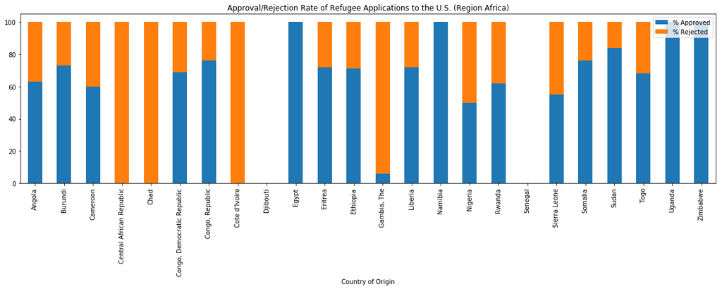

```python
#REPEAT THE SAME THING FOR AFRICA
df_africa = df.iloc[42:66]
index= df_africa['Region and country of birth'].values

#PLOT THE PERCENT APPROVED AND PERCENT REJECTED.
percentApproved = pd.to_numeric(df_africa['Percent approved']).values
percentRejected = 100 - pd.to_numeric(df_africa['Percent approved']).values

#MAKE A NEW DATAFRAME AND ADD THE TITLE
df_new = pd.DataFrame({'% Approved': percentApproved, '% Rejected':percentRejected }, index=index)
ax1 = df_new.plot.bar(stacked=True,figsize=(20,5))
ax1.set_xlabel('Country of Origin');
ax1.set_title('Approval/Rejection Rate of Refugee Applications to the U.S. (Region Africa)');
```

These three bargraphs highlight one possible factor that the U.S. takes into consideration when deciding whether or not to accept a refugee application: country of origin. It is clear that not every country, and not even every country in each region, had similar acceptance rates when applying to enter the U.S. in 2004. For example, refugees coming from Croatia had a much higher approval rate when applying to enter the U.S. than refugees coming from Tajikistan, even though both of these countries are in Europe. Similarly, refugees coming from Burma had a much higher approval rate than refugees coming from Sri Lanka, even though both of these countries are in Asia. There are similar patterns in Afria as well.

Overall, there were a large range in acceptance rates for different countries in 2004, which we would assume is due to how many people from these countries apply to enter the U.S. each year, what types of issues are going on in their countries of origin, and possibly other factors as well. We assume that these are trends that would affect acceptance rates every year, although they would probably change over time.

Now that we have learned more about how country of origin can affect the likliness of a person being accepted to enter the U.S. as a refugee, we decided we wanted to learn more about how the country the refugee is trying to enter can affect their chance of getting approved. For this analysis, we decided to look at different countries in Europe.

Below, we read in the csv data file that contains data on the percent of refugees that were accepted and rejected when applying to several different countries in Europe. It also breaks up the percent of refugees that were accepted based on subsidary protection, humanitarian reasons, as well as other reasons. After tidying up this data we then create a stacked bargraph that compares these acceptance/rejection rates for all of the different countries. This graph is shown below.

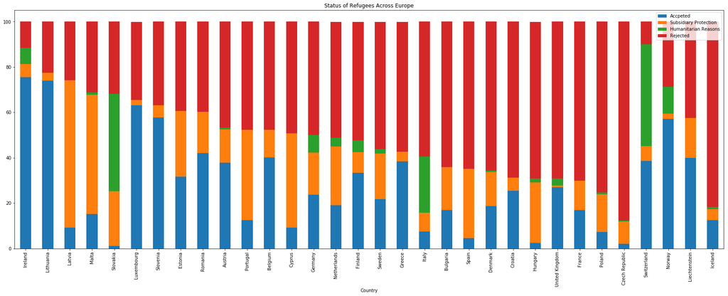

```python
#READ IN NEW DATAFRAME
df11 = pd.read_csv('data/asluym-rejections.csv')
#DROP COLUMNS WE DO NOT NEED AND CLEAN UP DATA
df11 = df11.drop(columns=['Unnamed: 5', 'Unnamed: 6'])
df11 = df11.loc[2:]
df11 = df11.rename(columns = {'Unnamed: 0':'Country'})
df11 = df11.dropna();

index1 = df11['Country']

#CLEAN UP THE DATA FORMATTING
refugeestatus = pd.to_numeric(df11['Refugee status'].values)
subsidiaryprotection = pd.to_numeric(df11['Subsidiary protection'].values)
humanitarian = pd.to_numeric(df11['Humanitarian reasons'].values)
rejected = pd.to_numeric(df11['Rejected'].values)

data2 = pd.DataFrame({'Accpeted': refugeestatus,'Subsidiary Protection': subsidiaryprotection, 'Humanitarian Reasons': humanitarian, 'Rejected':rejected}, index=index1)
ax2 = data2.plot.bar(stacked=True,figsize=(29,10), title="Status of Refugees Across Europe")
```

This graph gives us a lot of insight into how the country the refugee is trying to enter can affect their chance of getting approved (in addition to that refugee's country of origin). As we can see here, the Czech Republic has the highest rates of rejection, and Ireland and Switzerland have the lowest rates of rejection. Latvia has the highest rates of subsidiary protection, while the United Kingdom and Norway have the lowest rates of subsidiary protection. For humanitarian reasons, Slovakia, Italy and Switzerland have the highest rates. And finally, for accepted refguee status, Ireland and Lithuania have highest rates, and Slovakia, Hungary and the Czech Republic has the lowest rates. We assume that these different approval and rejection rates are due to different factors in the countries in question; for instance, that country's population could affect how many refugees they accept because they will probably accept less if they cannot support more people.

#### Part 4:

Based on our findings above (in Part 3), it is clear that country of origin as well as country of entrance can greatly affect whether or not a refugee is accepted or rejected. We wanted to find out if other attributes can affect this decision as well. Specifically, we wanted to look at the age and sex of the applicant as well as the year they applied to be a refugee.

```python
import pandas as pd
#READ IN NEW DATAFRAMES AND DROP UNNECESSARY COLUMNS
ml_df = pd.read_csv('data/migr_asydcfina_1_Data.csv')
ml_df = ml_df.drop(columns=['GEO', 'UNIT','Value','Flag and Footnotes','CITIZEN'])

ml_df.head()
```

|  | TIME | SEX | AGE | DECISION |
| --- | --- | --- | --- | --- |
| 0 | 2008 | Males | Less than 14 years | Total positive decisions |
| 1 | 2008 | Males | Less than 14 years | Geneva Convention status |
| 2 | 2008 | Males | Less than 14 years | Humanitarian status |
| 3 | 2008 | Males | Less than 14 years | Rejected |
| 4 | 2008 | Males | From 14 to 17 years | Total positive decisions |

0 is rejected, 1 is not rejected.

0 is female, 1 is male.

0 is less than 18 years. 1 is from 14 to 17 years. 2 is from 18 to 34 years. 3 is from 35 to 64 years. 4 is 65 years or over.

```python
#CLEAN UP THE DATA TO BE NUMERIC - FOR ML ALGORITHMS WE WANT THE VALUES TO BE NUMERIC.
ml_df.loc[ml_df.DECISION == 'Rejected', 'DECISION'] = 0
ml_df.loc[ml_df.DECISION == 'Geneva Convention status', 'DECISION'] = 1
ml_df.loc[ml_df.DECISION == 'Humanitarian status', 'DECISION'] = 1
ml_df.loc[ml_df.DECISION == 'Total positive decisions', 'DECISION'] = 1

ml_df.loc[ml_df.SEX == 'Females', 'SEX'] = 0
ml_df.loc[ml_df.SEX == 'Males', 'SEX'] = 1

ml_df.loc[ml_df.AGE == 'Less than 14 years', 'AGE'] = 0
ml_df.loc[ml_df.AGE == 'Less than 18 years', 'AGE'] = 0
ml_df.loc[ml_df.AGE == 'From 14 to 17 years', 'AGE'] = 1
ml_df.loc[ml_df.AGE == 'From 18 to 34 years', 'AGE'] = 2
ml_df.loc[ml_df.AGE == 'From 35 to 64 years', 'AGE'] = 3
ml_df.loc[ml_df.AGE == '65 years or over', 'AGE'] = 4

ml_df['TIME'] = pd.to_numeric(ml_df['TIME'])
targetdf = ml_df.loc[:, ml_df.columns != 'DECISION']
```

```python
from sklearn import datasets, linear_model
from sklearn.model_selection import train_test_split
from matplotlib import pyplot as plt
from sklearn.model_selection import train_test_split
from sklearn.neighbors import KNeighborsClassifier
from sklearn.metrics import accuracy_score
from sklearn.model_selection import KFold
from sklearn.metrics import classification_report
```

For more explanation on scikit learn, we encourage the following resource: https://scikit-learn.org/

```python
y = ml_df['DECISION']
# USE SCIKIT LEARN TO SPLIT DATA INTO TRAINING AND TESTING
train_features, test_features, train_labels, test_labels = train_test_split(targetdf, y, test_size = 0.25, random_state = 42)
```

```python
#USE KNN TO FIT A MODEL
neigh = KNeighborsClassifier(n_neighbors=3)
results = neigh.fit(train_features, train_labels)
```

```python
#USE KFOLD TO RUN A KFOLD TEST
kf = KFold(n_splits=10)
kf.get_n_splits(targetdf)

#THE TEST WILL INCLUDE PRINTING OUT A CLASSIFICATION REPORT AND ACCURACY SCORE FOR EVERY SINGLE TEST
for train_index, test_index in kf.split(targetdf):
    X_train, X_test = targetdf.iloc[train_index], targetdf.iloc[test_index]
    y_train, y_test = y[train_index], y[test_index]
    neigh.fit(X_train, y_train)
    y_pred = neigh.predict(X_test)
    print("Classification report")
    print(classification_report(y_test, y_pred))
    print("Accuracy score")
    print(accuracy_score(y_test, y_pred))
```

```
Classification report
             precision    recall  f1-score   support

          0       0.25      0.25      0.25      6120
          1       0.75      0.75      0.75     18360

avg / total       0.62      0.62      0.62     24480

Accuracy score
0.625
Classification report
             precision    recall  f1-score   support

          0       0.00      0.00      0.00      6120
          1       0.75      1.00      0.86     18360

avg / total       0.56      0.75      0.64     24480

Accuracy score
0.75
```

```
Classification report
             precision    recall  f1-score   support

          0       0.00      0.00      0.00      6120
          1       0.75      1.00      0.86     18360

avg / total       0.56      0.75      0.64     24480

Accuracy score
0.75
Classification report
             precision    recall  f1-score   support

          0       0.25      0.08      0.12      6120
          1       0.75      0.92      0.83     18360

avg / total       0.62      0.71      0.65     24480

Accuracy score
0.708333333333
Classification report
             precision    recall  f1-score   support

          0       0.25      0.25      0.25      6120
          1       0.75      0.75      0.75     18360

avg / total       0.62      0.62      0.62     24480

Accuracy score
0.625
Classification report
             precision    recall  f1-score   support

          0       0.00      0.00      0.00      6120
          1       0.75      1.00      0.86     18360

avg / total       0.56      0.75      0.64     24480

Accuracy score
0.75
```

[output cut: 25 more lines]

```

avg / total       0.56      0.75      0.64     24480

Accuracy score
0.75
Classification report
             precision    recall  f1-score   support

          0       0.25      0.17      0.20      6120
          1       0.75      0.83      0.79     18360

avg / total       0.62      0.67      0.64     24480

Accuracy score
0.666666666667
```

NULL HYPOTHESIS: Age and sex can predict whether a person gets accepted or rejected.

- We wanted to see, if we took the location away, is there a pattern between whether a person gets rejected or not rejected with only a few attributes?
- We created a KNN model predicting rejection or non-rejection based on gender, age, and year of application.
- Our K Fold test shows that our KNN model was 60-75% accurate for each KNN fold.
- We also printed out a classification report, which shows us that although we would need more data to make it more accurate, it has potential right now to predict.

```python
import statsmodels.api as sm

#DO A STATISTIC MODEL ON THE TESTING AND PREDICTIONS AND PRINT OUT THE SUMMARY
model = sm.OLS(y_test, y_pred)
results = model.fit()
results.summary()
```

OLS Regression Results

| Dep. Variable: | DECISION | R-squared: | 0.625 |
| --- | --- | --- | --- |
| Model: | OLS | Adj. R-squared: | 0.625 |
| Method: | Least Squares | F-statistic: | 4.080e+04 |
| Date: | Fri, 14 Dec 2018 | Prob (F-statistic): | 0.00 |
| Time: | 04:11:35 | Log-Likelihood: | -19209. |
| No. Observations: | 24480 | AIC: | 3.842e+04 |
| Df Residuals: | 24479 | BIC: | 3.843e+04 |
| Df Model: | 1 |  |  |
| Covariance Type: | nonrobust |  |  |

|  | coef | std err | t | P>\|t\| | [0.025 | 0.975] |
| --- | --- | --- | --- | --- | --- | --- |
| x1 | 0.7500 | 0.004 | 201.986 | 0.000 | 0.743 | 0.757 |

| Omnibus: | 673.107 | Durbin-Watson: | 1.944 |
| --- | --- | --- | --- |
| Prob(Omnibus): | 0.000 | Jarque-Bera (JB): | 704.270 |
| Skew: | -0.399 | Prob(JB): | 1.17e-153 |
| Kurtosis: | 2.772 | Cond. No. | 1.00 |

Warnings:  
[1] Standard Errors assume that the covariance matrix of the errors is correctly specified.

From this result, we can see a lot of future improvements into the strength of predicting whether or not a refugee will get accepted. Some further work on this could be running the tests with more data, in order to get a more accurate model.

## CONCLUSION

Throughout this tutorial, we gained several insights into refugees and came up with a few final messages for readers to take away:

First, in Part 1 we learned that over time, the number of refugees entering countries as well as the regions these refugees are coming from greatly changes over time. There is also great differences in the amount of refugees being allowed to enter different countries (for instance, Germany generally accepts more refugees than the U.S., France, or the U.K.). Next, in Part 2 we learned more about the trends of where different refugees come from when entering the U.S. over the past few decades; it is clear that in different time periods, different regions have much greater amounts of refugees. We also learned more about the age of refugees entering the U.S. in recent years. Then, in Part 3 we learned more about how country of origin as well as country of entrance can affect whether or not a refugee applicant is accepted or rejected. It is obvious that country of origin is a factor the U.S. considers when reviewing refugee applications, and it is also clear that each country has different attitudes towards accepting refugees. Finally, in Part 4 we learned more about what other factors affect whether or not a refugee is accepted and how we can use these factors to actually predict whether or not someone is accepted historically.

This tutorial shows how data science can be utilized to gain much deeper understanding into global refugees and historically help predict whether or not a refugee will be accepted based on their sex, age, and year they apply.